# Índice de Transparência nos Tribunais de Justiça

## Metodologia

### Índice de Facilidade

> O índice de facilidade é constante para todos os órgãos, pois os dados são acessados e extraídos da mesma plataforma do CNJ. Esses valores são travados para todos os tribunais e, portanto, refletem o estado da plataforma.
- `nao_requer_login`: se para acessar a planilha é preciso fazer login (1 ponto, o painel do CNJ não requer login): $1$
- `nao_requer_captcha`: se para acessar a planilha é preciso digitar captcha (1 ponto, o painel do CNJ não requer captcha): $1$
- `acesso`: se precisa simular cliques para coleta de dados automatizada (1 ponto, o painel do CNJ requer simulação de cliques): $0$
- `formato_consistente`: se o formato da planilha é sempre o mesmo ao longo do tempo (1 ponto, o painel do CNJ é padronizado): $1$
- `estritamente_tabular`: se a planilha do CNJ está em um formato que precisa de tratamento para tabulação (1 ponto, painel apresenta dados estritamente tabulares): $1$

A somatória para todos os órgãos será sempre:

$$\textrm{Índice Facilidade} = (1+1+0+1+1) / 5 = 4/5 = 0,8$$

### Índice de Completude

- `tem_lotacao`: Se tem informação de lotação (1 ponto, nenhum órgão tem): $0$
- `tem_cargo`: Se tem informação do cargo do membro (1ponto, nenhum órgão tem): $0$
- `tem_matricula`: Se tem informação de matrícula (1 ponto, nenhum órgão tem): $0$
- `receita_base`: Se tem dados de receita-base (1 ponto, todos os órgãos tem): $1$
- `despesas`: Se tem dados de despesa (1 ponto, todos os órgãos tem): $1$
- `outras_receitas`: Se tem dados de outras receitas (1 ponto, todos os órgãos tem): $1$

A somatória para todos os órgãos será sempre:

$$\textrm{Índice Completude} = (0+0+0+1+1+1) / 6 = 3/6 = 0,5$$

E quando um órgão não sobe a planilha de pagamentos no CNJ ele zera em todos os quesitos.

### Índice de transparência

$$\textrm{Índice Transparência} = \frac{2 \times \textrm{Índice Facilidade} \times \textrm{Índice Completude}}{\textrm{Índice Facilidade} + \textrm{Índice Completude}}$$

$$\textrm{Índice Transparência} = \frac{2 \times 0,8 \times 0,5}{0,8+0,5} = \frac{0,8}{1,3} \approx 0,62$$
Caso algum dos índices seja igual a zero, então o índice de transparência também será zero.

## Transparência nos tribunais de justiça

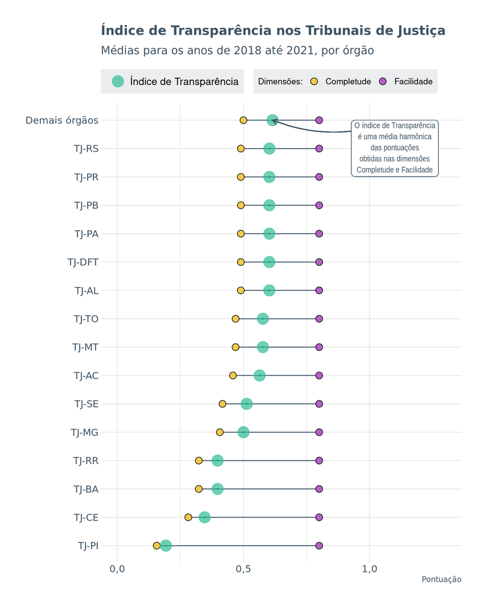

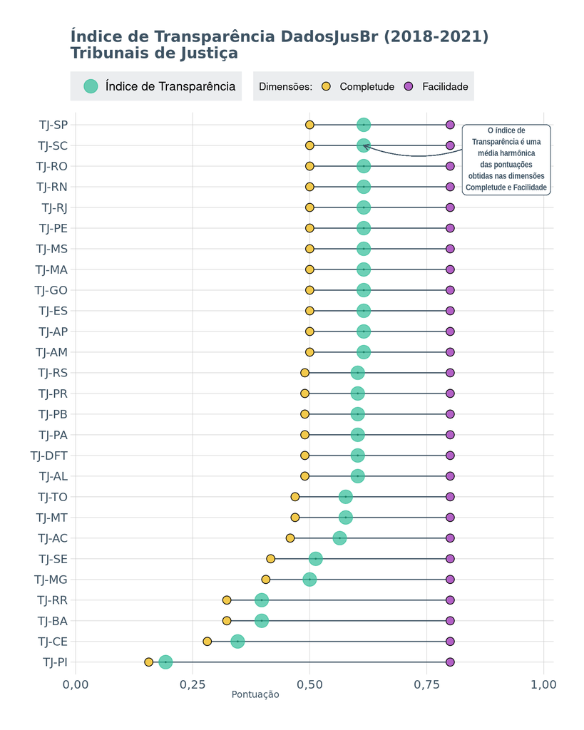

[figure not shown]

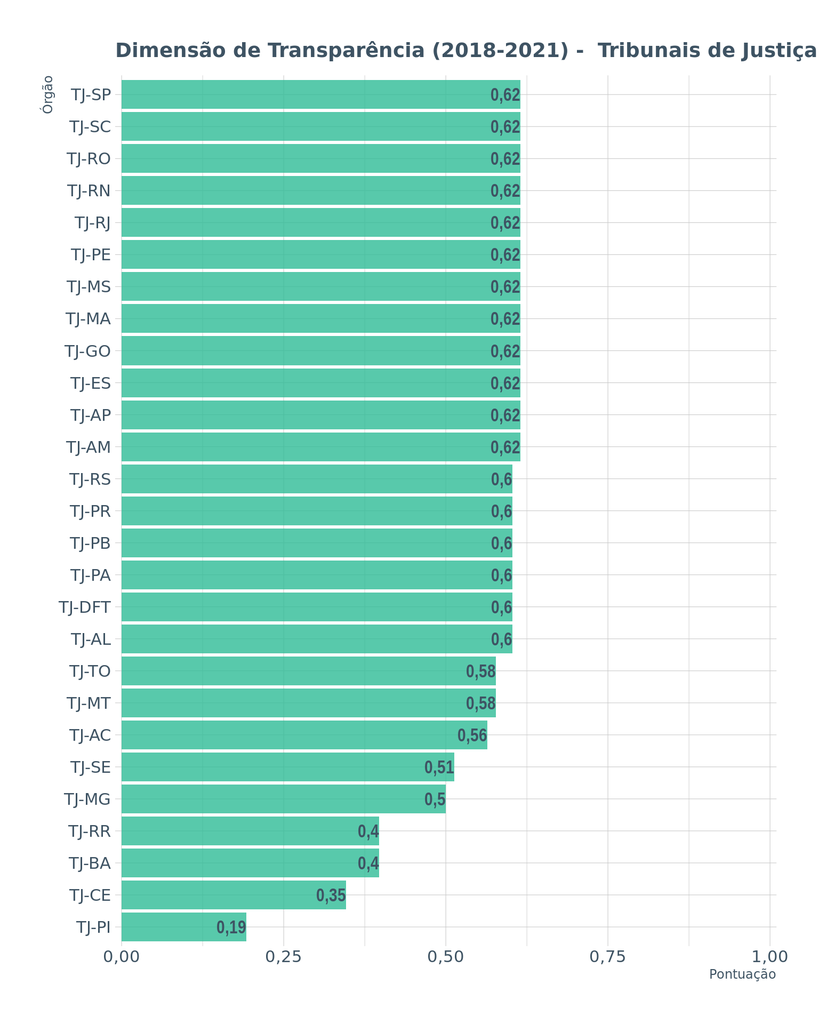

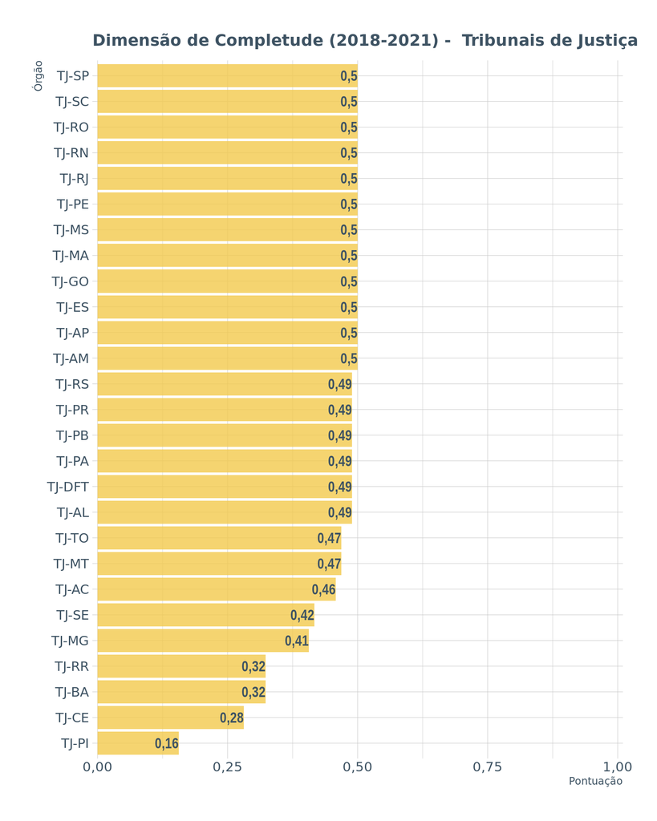

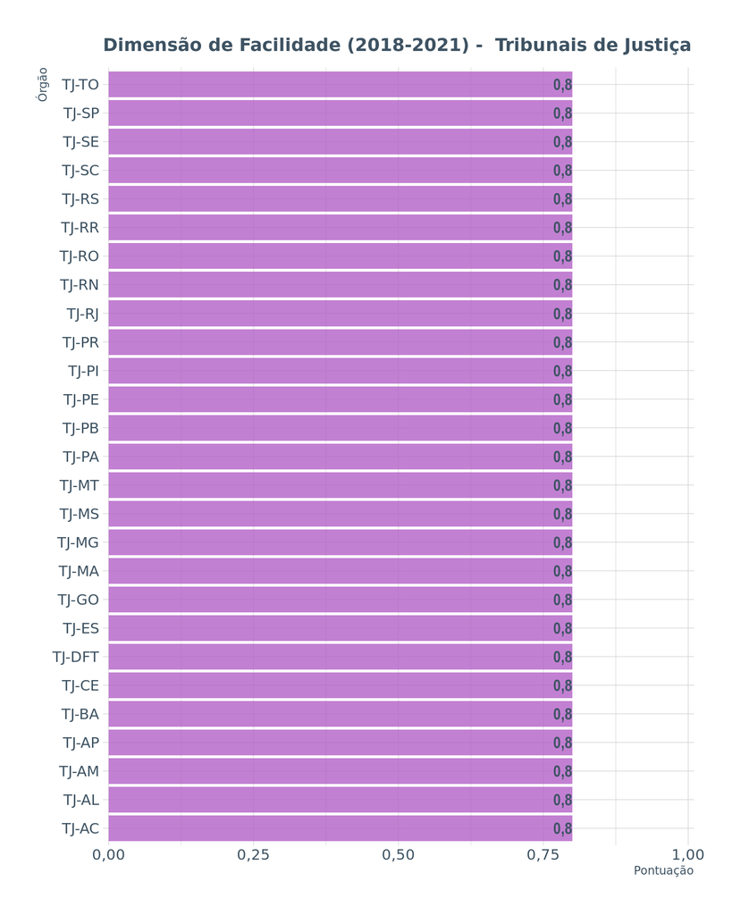

## Valores registrados mês a mês

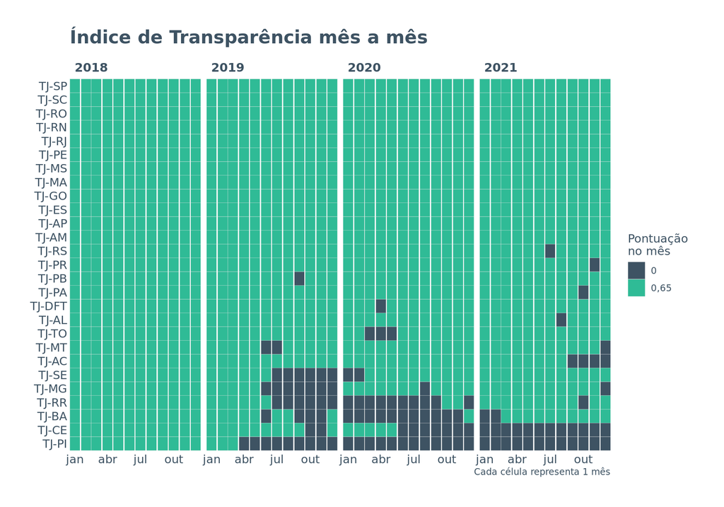

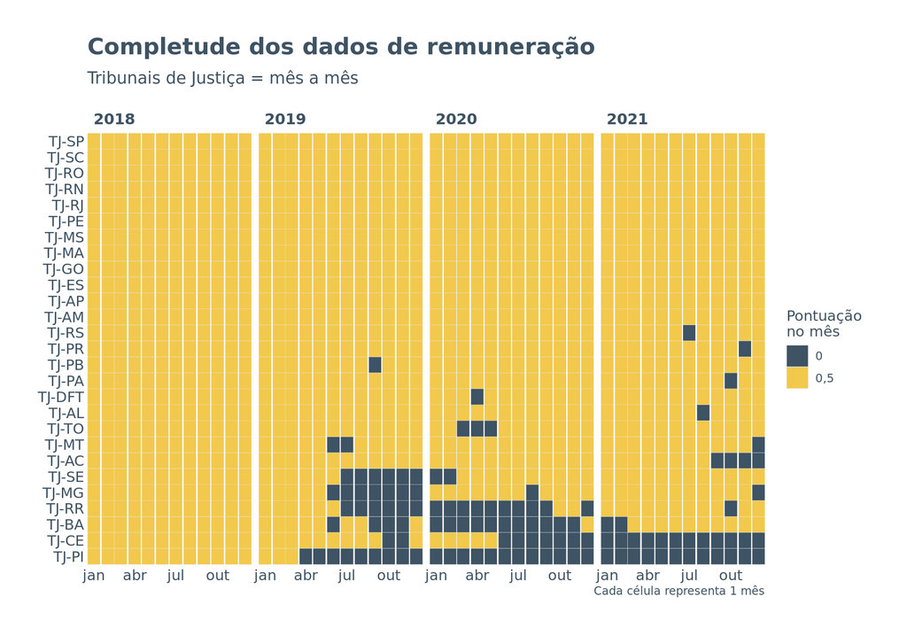

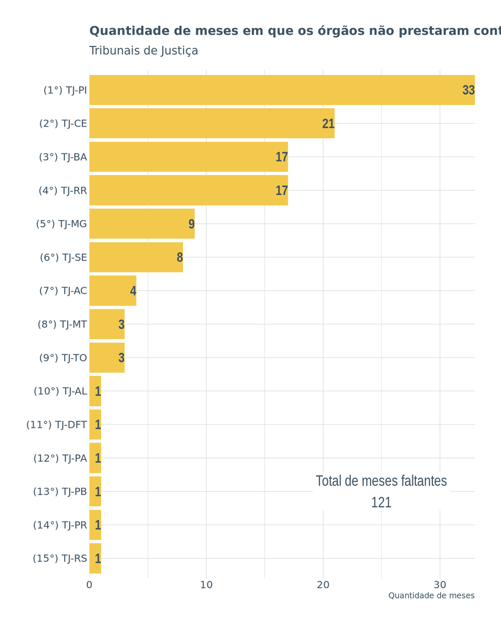

## Completude dos dados

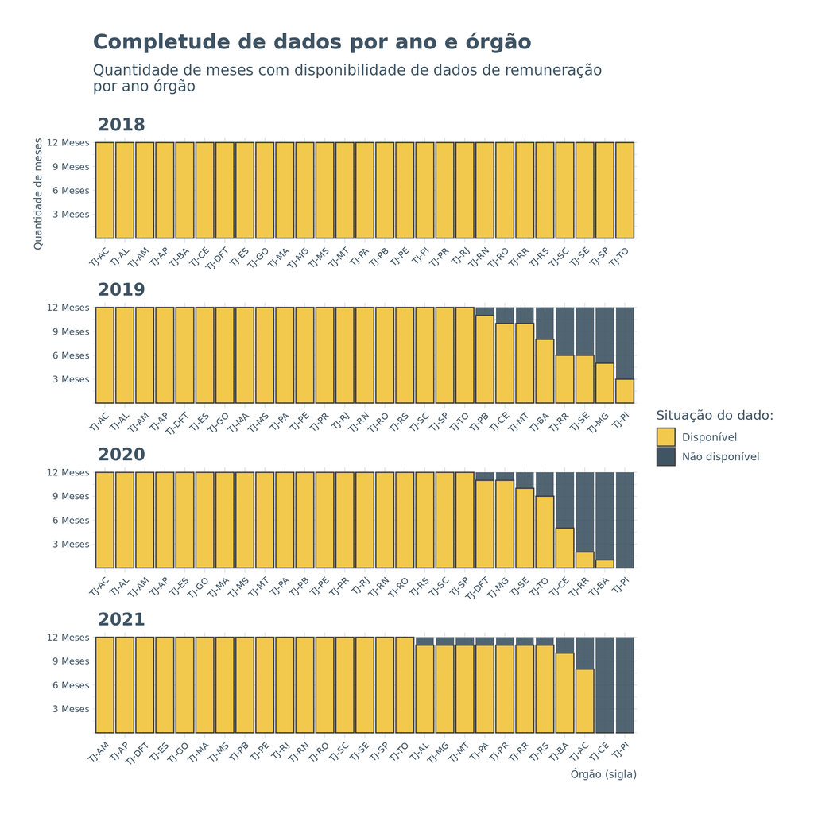

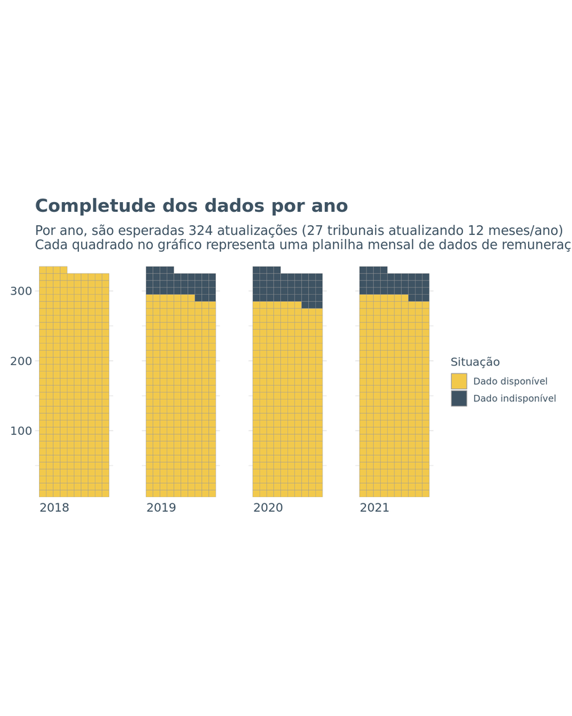

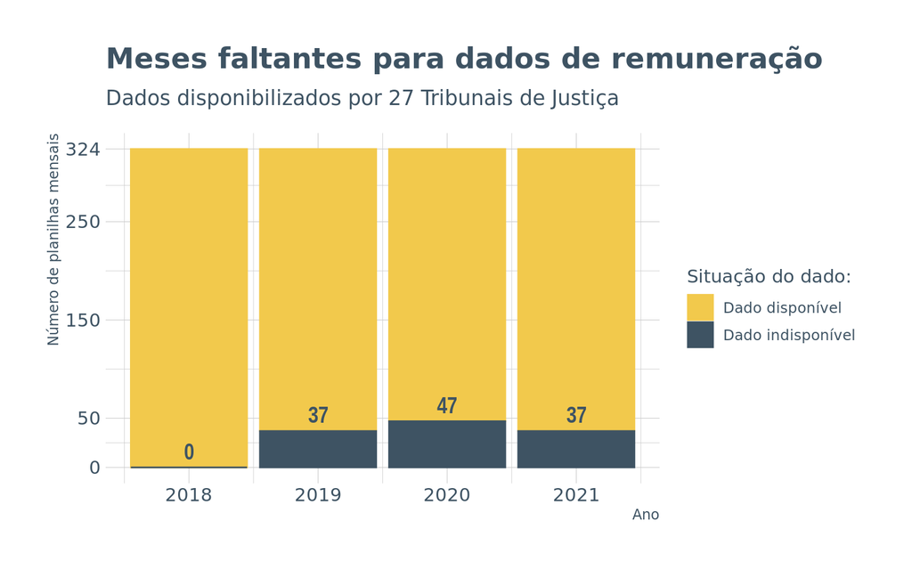

## Médias anuais do índice de Transparência

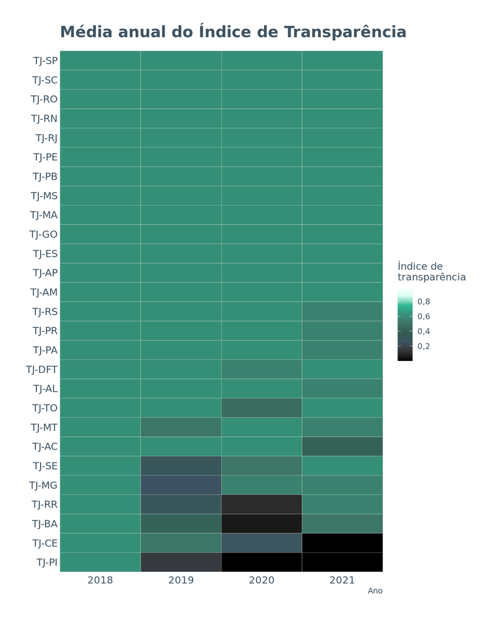

## Médias anuais do índice de Completude

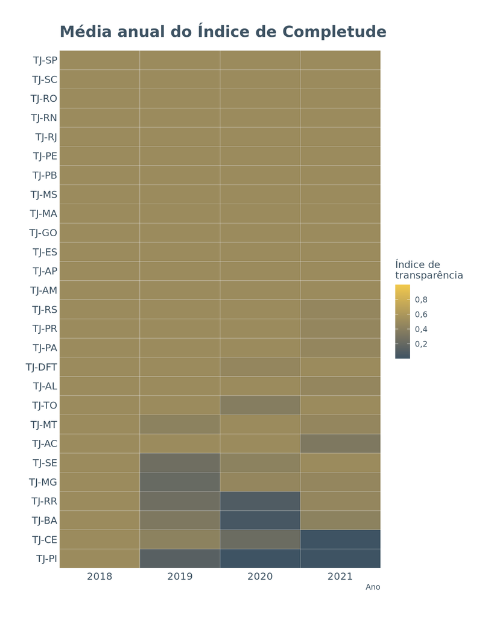

## Contracheques faltantes

Contagem de contracheques

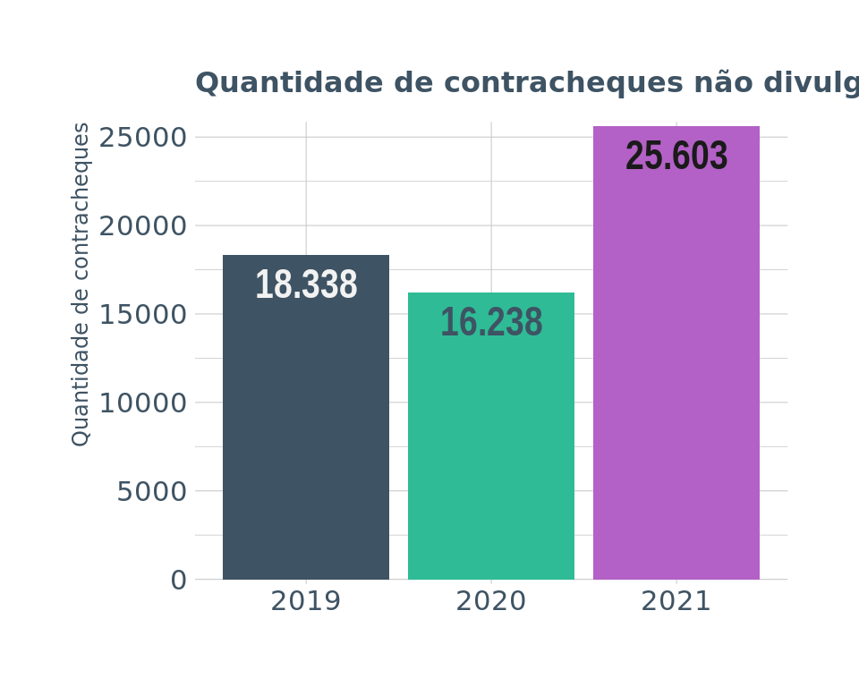

Percentual de contracheques

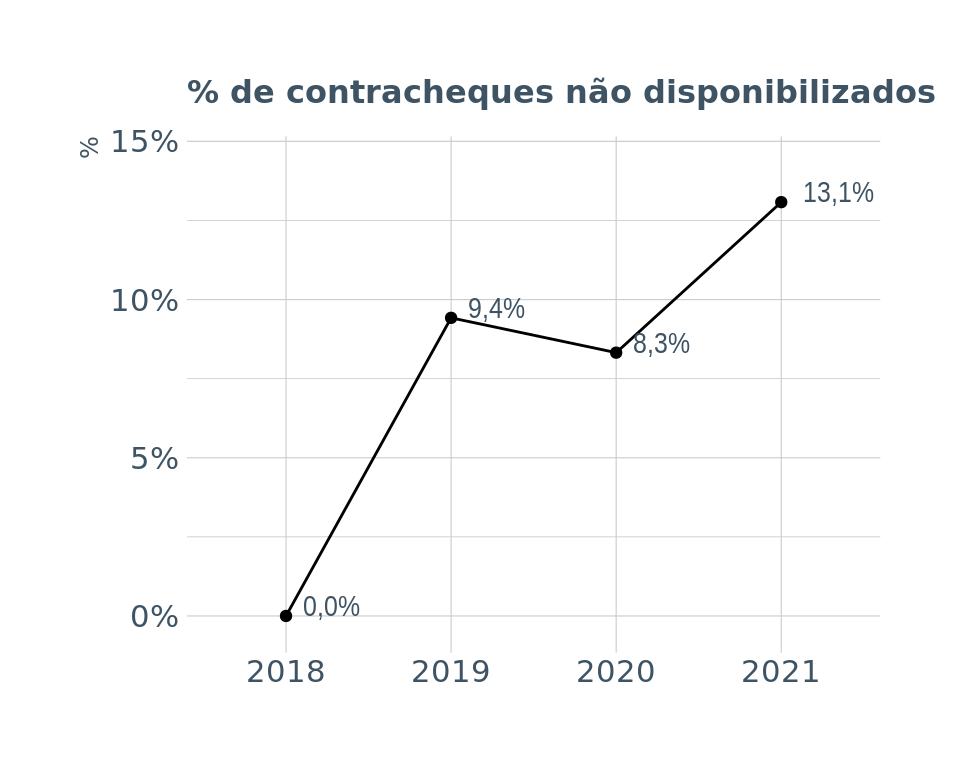

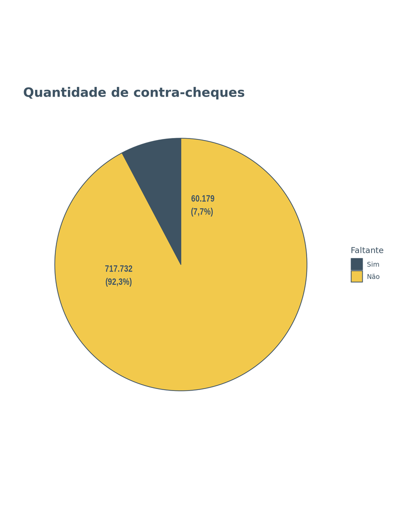

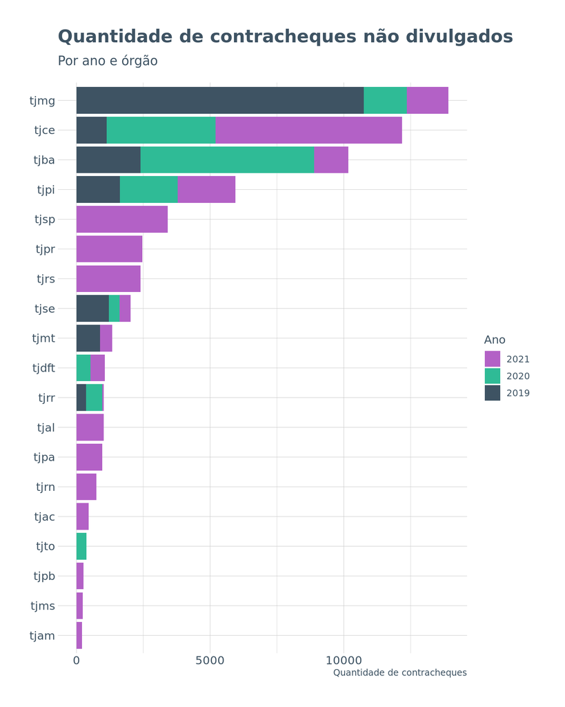

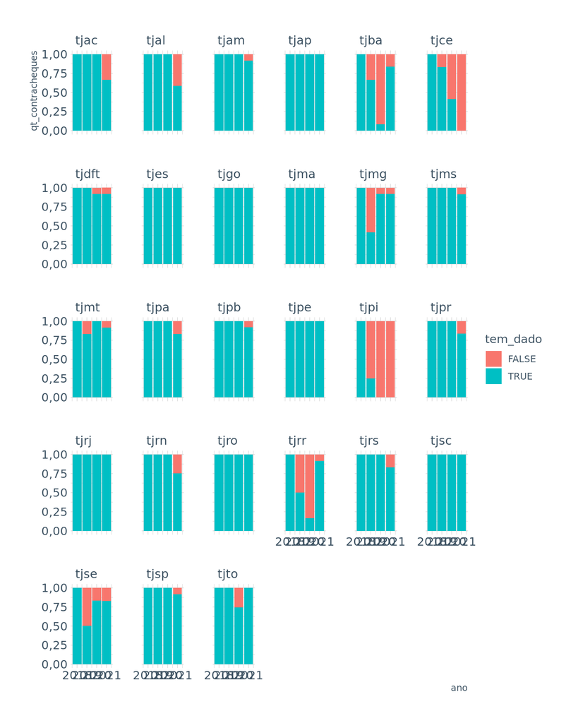